# Trabalho Séries Temporais

Adriane Akemi nUSP: 11915623

Álvaro Valentim nUSP: 10392150

Emerson Miady nUSP: 11207943

# Objetivo

O objetivo do grupo é usar as técnicas de séries temporais para ajustar algum modelo em um conjunto de dados, aplicando as seguintes etapas:

1. Análise exploratória;
2. Ajuste do modelo;
3. Análise de resíduos;
4. Previsão.

# Dados

Os dados utilizados são de vendas mensais (em dolar australiano) de uma loja de Souvenir localizada em um beach resort em Queensland, Australia, no período de 1987 a 1993, contendo assim, 84 observações temporais.

```r
dat <- scan("http://robjhyndman.com/tsdldata/data/fancy.dat")
dat <- ts(dat, frequency=12, start=c(1987,1))
dat
```

```
##            Jan       Feb       Mar       Apr       May       Jun       Jul
## 1987   1664.81   2397.53   2840.71   3547.29   3752.96   3714.74   4349.61
## 1988   2499.81   5198.24   7225.14   4806.03   5900.88   4951.34   6179.12
## 1989   4717.02   5702.63   9957.58   5304.78   6492.43   6630.80   7349.62
## 1990   5921.10   5814.58  12421.25   6369.77   7609.12   7224.75   8121.22
## 1991   4826.64   6470.23   9638.77   8821.17   8722.37  10209.48  11276.55
## 1992   7615.03   9849.69  14558.40  11587.33   9332.56  13082.09  16732.78
## 1993  10243.24  11266.88  21826.84  17357.33  15997.79  18601.53  26155.15
##            Aug       Sep       Oct       Nov       Dec
## 1987   3566.34   5021.82   6423.48   7600.60  19756.21
## 1988   4752.15   5496.43   5835.10  12600.08  28541.72
## 1989   8176.62   8573.17   9690.50  15151.84  34061.01
## 1990   7979.25   8093.06   8476.70  17914.66  30114.41
## 1991  12552.22  11637.39  13606.89  21822.11  45060.69
## 1992  19888.61  23933.38  25391.35  36024.80  80721.71
## 1993  28586.52  30505.41  30821.33  46634.38 104660.67
```

# Análise exploratória

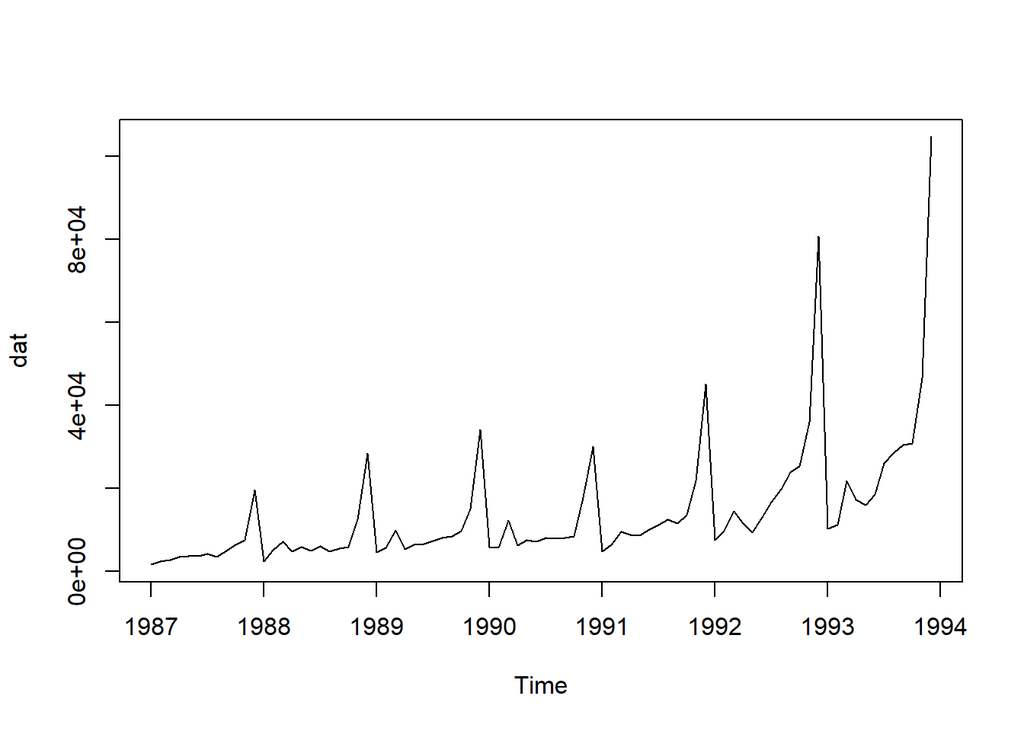

```r
plot.ts(dat)
```

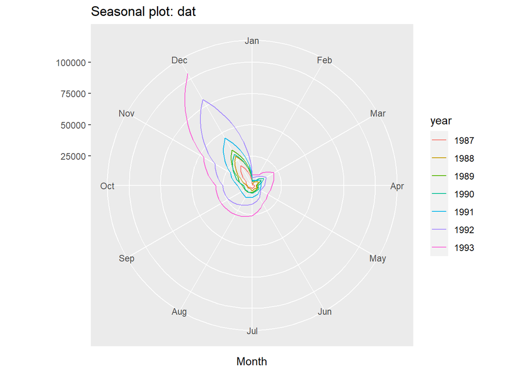

```r
ggseasonplot(dat, polar = TRUE)
```

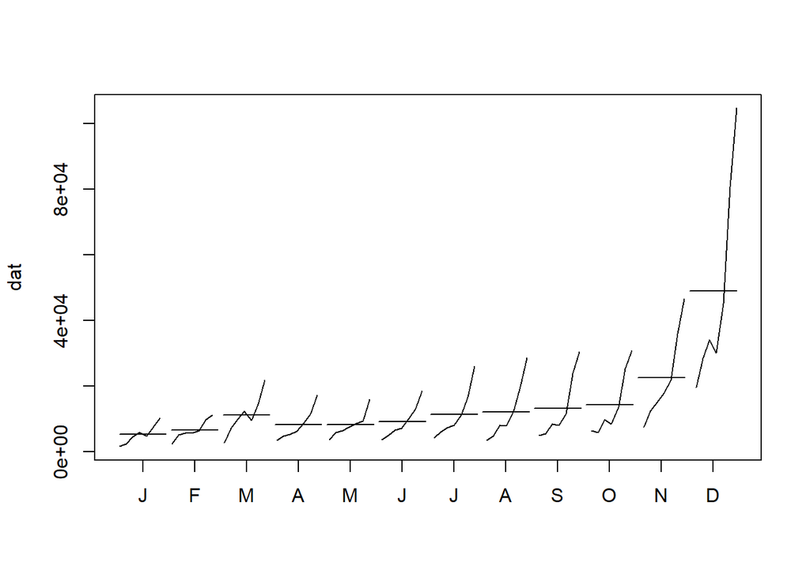

```r
monthplot(dat)
```

O primeiro plot mostra uma tendência de crescimento da série conforme se passa os anos, indicando que a loja está em constante crescimento. Além disso, existe uma certa periodicidade nas vendas mensais.

O segundo plot é uma confirmação do primeiro, já que em todos os anos o formato da curva se mantém aproximadamente, porém vemos um crescimento de sua área.

O último plot indica que, as médias de vendas (linhas horizontais) aumentam no final do ano, atigindo um pico em dezembro.

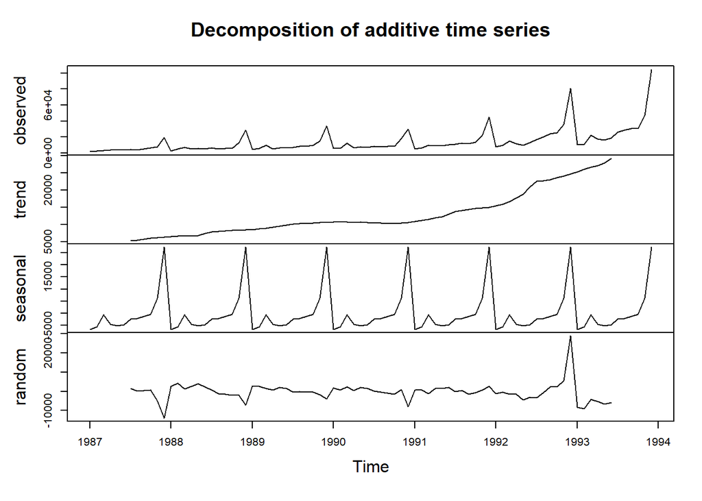

```r
plot(decompose(dat))
```

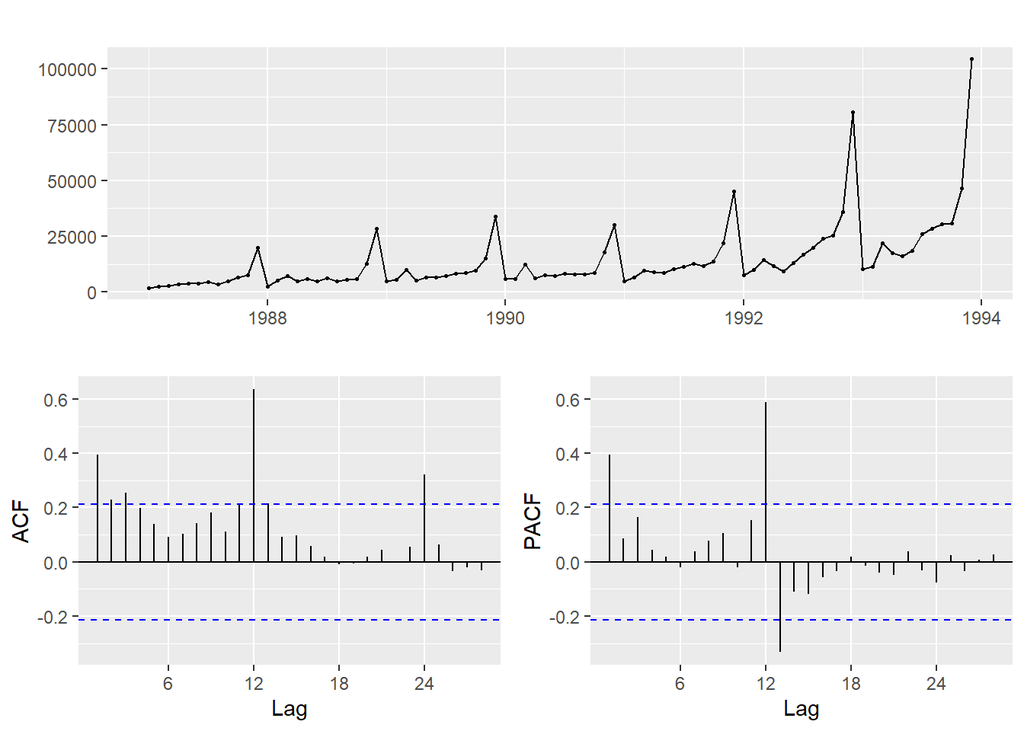

```r
ggtsdisplay(dat)
```

Da decomposição da série, vemos que existe sazonalidade e uma clara tendência de crescimento nas vendas (série não estacionária), corroborando com as observações feitas anteriormente. Para tratar a tendência, podemos utilizar a diferença de lags entre as observações, ou seja, alterando o argumento “d” do ARIMA.

Vamos fazer o teste ADF (raiz unitária) com $d = 1$ para verificar se a série ainda é não estacionária.

```r
adf.test(diff(dat))
```

```
##
##  Augmented Dickey-Fuller Test
##
## data:  diff(dat)
## Dickey-Fuller = -3.7374, Lag order = 4, p-value = 0.02655
## alternative hypothesis: stationary
```

O $d = 1$ já indica que a série é estacionária, sendo assim, usaremos este parâmetro para o ARIMA.

Para achar o “p” do AR, olhamos para a PACF, e um valor que queremos testar é 1. Isto porque existe um valor significante na primeira autocorrelação parcial. Já para descobrir o “q” do MA, observamos a FAC, e analogamente, escolhemos o “q” igual a 1.

Então nosso modelo até o momento é $ARIMA(1, 1, 1)$.

Dado que existe sazonalidade, vamos incluir a componente sazonal neste modelo.

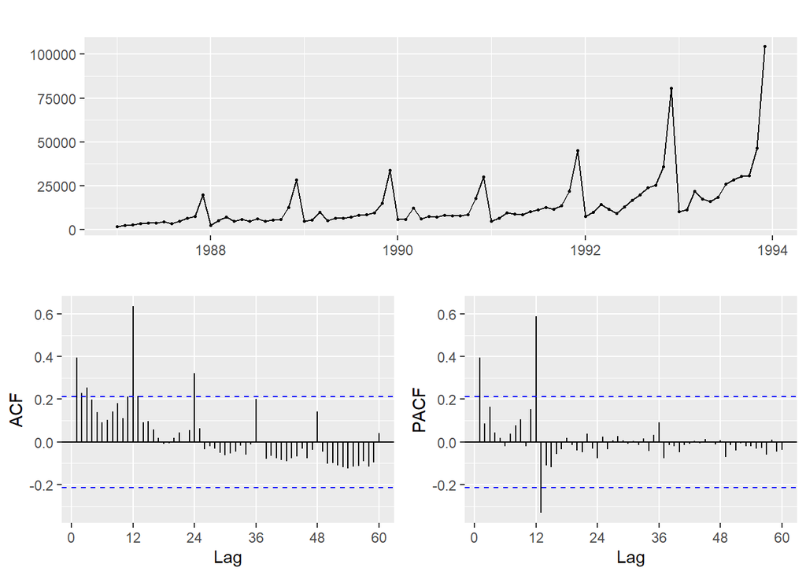

```r
ggtsdisplay(dat, lag.max=60)
```

Os gráficos acima são os mesmos que os anteriores, só alterando o número de lags. No PACF, vemos um truncamento periódico (período = 12) em t = 12, e além disso, temos os lags periódicos do ACF decaindo lentamente, em t = 12, 24, 36…

Sendo assim, supomos que o parâmetro “P” do SARIMA deve ser 1 e o “Q” é 0.

Logo, o modelo que supomos foi um $SARIMA(1, 1, 1)(1, 1, 0)_{12}$

# Ajuste

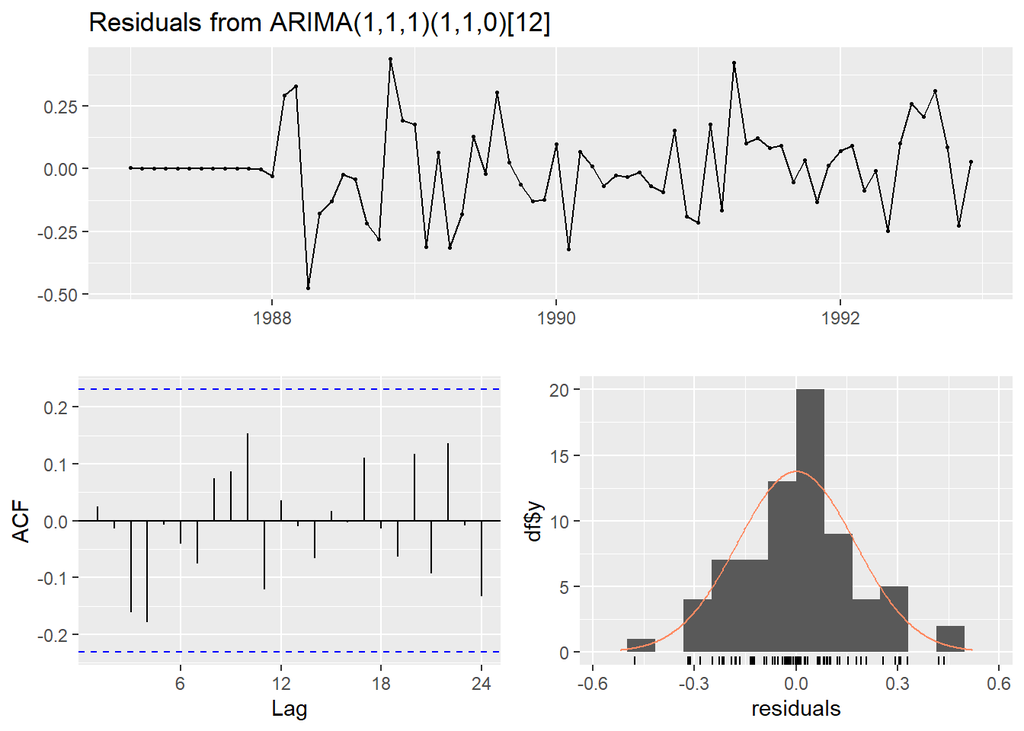

```
##
##  Ljung-Box test
##
## data:  Residuals from ARIMA(1,1,1)(1,1,0)[12]
## Q* = 10.112, df = 11, p-value = 0.5204
##
## Model df: 3.   Total lags used: 14
```

```r
training <- window(dat, end = c(1992,12))
test <- window(dat, start = c(1993,1))
fit <- Arima(training, order = c(1,1,1), seasonal = c(1,1,0),
                 method = "ML", lambda = 0)

checkresiduals(fit)
```

O teste de Ljung-Box verifica se a autocorrelação dos resíduos é igual a 0. Como o p-valor obtido foi maior que o nível de significância de 5%, não rejeitamos a hipótese nula e portanto, os resíduos não são autocorrelacionados.

Vemos também que, as autocorrelações do ACF não passam da banda de confiança e a distribuição dos resíduos aparenta ser Normal.

Para testar a normalidade deles, vamos usar o teste de Shapiro Wilk.

```r
shapiro.test(fit$residuals)
```

```
##
##  Shapiro-Wilk normality test
##
## data:  fit$residuals
## W = 0.9775, p-value = 0.2239
```

```r
mean(fit$residuals)
```

```
## [1] 0.0003959808
```

A média dos resíduos foi praticamente 0, mostrando evidências de que a distribuição deles é $N(0, \sigma^2)$.

# Predição

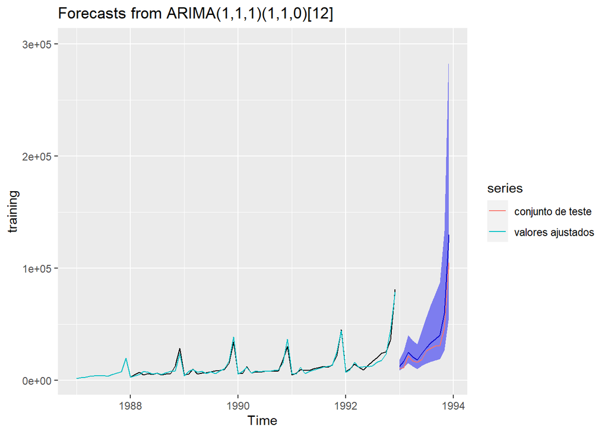

```r
forc <- forecast(object = fit, h=12, level = 0.95)


autoplot(forc) + autolayer(test, series = "conjunto de teste") + autolayer(fitted(forc), series = "valores ajustados")
```

```r
accuracy(forc, test)
```

```
##                        ME     RMSE      MAE        MPE     MAPE      MASE
## Training set    -8.001654 2247.371 1436.015  -1.450601 12.56400 0.3834691
## Test set     -6839.544870 9309.593 6839.545 -22.730360 22.73036 1.8264110
##                    ACF1 Theil's U
## Training set 0.05633702        NA
## Test set     0.40528354 0.6266895
```

# Conclusão